# 泰坦尼克号生还者预测

## **目标**

本项目由 Kaggle 发起，目标是对泰坦尼克号失事的乘客进行生还概率的预测分析。

## 数据源

数据由 Kaggle 提供，分别有训练集train.csv 和 测试集test.csv。

下面开始对数据集进行处理。

## 1.初识数据

```python
import pandas as pd
import numpy as np
import seaborn as sns
import xgboost as xgb
import matplotlib.pyplot as plt

from IPython.display import display
from sklearn.preprocessing import StandardScaler
from sklearn import cross_validation
from sklearn.metrics import accuracy_score

from sklearn.tree import DecisionTreeClassifier
from sklearn.ensemble import RandomForestRegressor
from sklearn.ensemble import (RandomForestClassifier, AdaBoostClassifier,
                              GradientBoostingClassifier, ExtraTreesClassifier)

from sklearn.svm import SVC
from sklearn.model_selection import KFold
from sklearn.model_selection import GridSearchCV
from sklearn.model_selection import train_test_split
from sklearn.metrics import make_scorer

%matplotlib inline
```

```python
data_train = pd.read_csv('train.csv')
data_test = pd.read_csv('test.csv')

full_data = [data_train, data_test]
data_train.head()
```

|  | PassengerId | Survived | Pclass | Name | Sex | Age | SibSp | Parch | Ticket | Fare | Cabin | Embarked |
| --- | --- | --- | --- | --- | --- | --- | --- | --- | --- | --- | --- | --- |
| 0 | 1 | 0 | 3 | Braund, Mr. Owen Harris | male | 22.0 | 1 | 0 | A/5 21171 | 7.2500 | NaN | S |
| 1 | 2 | 1 | 1 | Cumings, Mrs. John Bradley (Florence Briggs Th... | female | 38.0 | 1 | 0 | PC 17599 | 71.2833 | C85 | C |
| 2 | 3 | 1 | 3 | Heikkinen, Miss. Laina | female | 26.0 | 0 | 0 | STON/O2. 3101282 | 7.9250 | NaN | S |
| 3 | 4 | 1 | 1 | Futrelle, Mrs. Jacques Heath (Lily May Peel) | female | 35.0 | 1 | 0 | 113803 | 53.1000 | C123 | S |
| 4 | 5 | 0 | 3 | Allen, Mr. William Henry | male | 35.0 | 0 | 0 | 373450 | 8.0500 | NaN | S |

发现特征信息有很多：

- **PassengerId：** 乘客ID
- **Pclass：** 乘客等级(1/2/3等舱位)
- **Name：** 乘客姓名
- **Sex：** 性别
- **Age：** 年龄
- **SibSp：** 堂兄弟/妹个数
- **Parch：** 父母与小孩个数
- **Ticket：** 船票信息
- **Fare：** 票价
- **Cabin：** 客舱
- **Embarked：** 登船港口

目标信息则是生还：

- **Survived:** 生还

## 2.数据分析

下面继续看这些字段信息的完整性（是否有缺失或者异常值），以及它们各自对目标变量（生还概率）的影响。

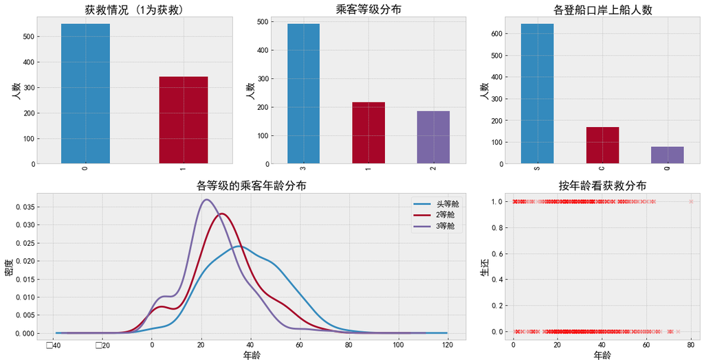

```python
fig = plt.figure(figsize=(20,10))
plt.style.use("bmh")
plt.rc('font', family='SimHei', size=13)
fig.set(alpha=0.4)

# 获救人数与遇难人数对比统计
plt.subplot2grid((2,3),(0,0))
data_train.Survived.value_counts().plot(kind='bar')
plt.title(u"获救情况 (1为获救)")
plt.ylabel(u"人数")

# 乘客等级人数统计
plt.subplot2grid((2,3),(0,1))
data_train.Pclass.value_counts().plot(kind="bar")
plt.ylabel(u"人数")
plt.title(u"乘客等级分布")

# 各登船港口上船人数统计
plt.subplot2grid((2,3),(0,2))
data_train.Embarked.value_counts().plot(kind='bar')
plt.title(u"各登船口岸上船人数")
plt.ylabel(u"人数")

# 各等级的乘客年龄分布
plt.subplot2grid((2,3),(1,0), colspan=2)
data_train.Age[data_train.Pclass == 1].plot(kind='kde', linewidth=3)
data_train.Age[data_train.Pclass == 2].plot(kind='kde', linewidth=3)
data_train.Age[data_train.Pclass == 3].plot(kind='kde', linewidth=3)
plt.xlabel(u"年龄")
plt.ylabel(u"密度")
plt.title(u"各等级的乘客年龄分布")
plt.legend((u'头等舱', u'2等舱',u'3等舱'),loc='best')

# 按年龄看获救分布
plt.subplot2grid((2,3),(1,2))
plt.scatter(data_train.Age,data_train.Survived, color='r', alpha=0.2, marker='x')
plt.xlabel(u"年龄")
plt.ylabel(u"生还")
plt.title(u"按年龄看获救分布")

plt.show()
```

### 结论：

- **获救人数对比：**可以看出获救的乘客（300+）明显少于遇难的乘客（500+）；
- **等级人数对比：**3等舱的人数最多（500），其次是1等舱（200+）；
- **登船口人数对比：**S登船港口人数占绝大部分（600+），其余两个很少；
- **各等级的乘客年龄分布：**年龄分布类似正态分布曲线。可以看出所有等级的乘客中，大部分乘客的年龄集中在20-40之间的中间年龄段，而两端的乘客（老人和小孩）人数不多；
- **年龄看获救分布：**从这个图的生还和遇难人数来看，看不出什么明显区别；

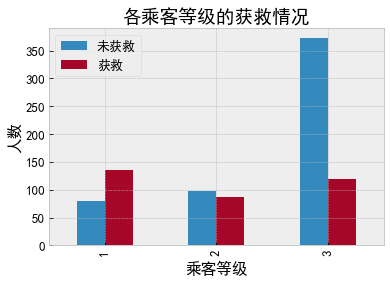

```python
# 看看各乘客等级的获救情况
Survived_0 = data_train.Pclass[data_train.Survived == 0].value_counts()
Survived_1 = data_train.Pclass[data_train.Survived == 1].value_counts()
df=pd.DataFrame({u'获救':Survived_1, u'未获救':Survived_0})
df.plot(kind='bar')
plt.title(u"各乘客等级的获救情况")
plt.xlabel(u"乘客等级")
plt.ylabel(u"人数")
plt.show()
```

### **结论：**

等级1的乘客获救率最大，等级2未获救略高与获救，而等级3的乘客未获救人数远远超过获救人数。这说明了社会等级的特征对于是否获救有着很明显的影响。

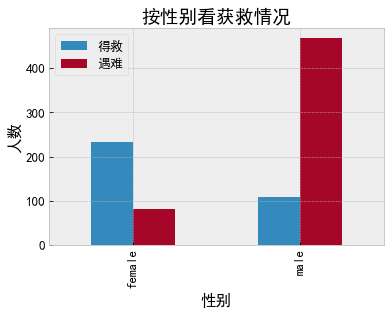

```python
# #看看各性别的获救情况
Survived_n = data_train.Sex[data_train.Survived == 0].value_counts()
Survived_y = data_train.Sex[data_train.Survived == 1].value_counts()
df2=pd.DataFrame({u'遇难':Survived_n, u'得救':Survived_y})
df2.plot(kind='bar')
plt.title(u"按性别看获救情况")
plt.xlabel(u"性别")
plt.ylabel(u"人数")
plt.show()
```

### **结论：**

从统计图中观察到，虽然女性总人数少于男性人数，但是女性得救的机会远远大于男性。性别对是否获救也有很大的影响。

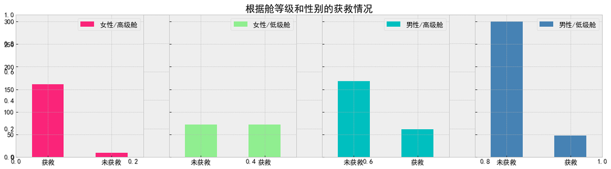

```python
#然后我们再来看看各种舱级别情况下各性别的获救情况
fig=plt.figure(figsize=(20,5))
plt.style.use("bmh")
fig.set(alpha=0.65)
plt.title(u"根据舱等级和性别的获救情况")

ax1=fig.add_subplot(141)
data_train.Survived[data_train.Sex == 'female'][data_train.Pclass != 3].value_counts().plot(kind='bar', label="female highclass", color='#FA2479')
ax1.set_xticklabels([u"获救", u"未获救"], rotation=0)
plt.legend([u"女性/高级舱"], loc='best')

ax2=fig.add_subplot(142, sharey=ax1)
data_train.Survived[data_train.Sex == 'female'][data_train.Pclass == 3].value_counts().plot(kind='bar', label='female, low class', color='lightgreen')
ax2.set_xticklabels([u"未获救", u"获救"], rotation=0)
plt.legend([u"女性/低级舱"], loc='best')

ax3=fig.add_subplot(143, sharey=ax1)
data_train.Survived[data_train.Sex == 'male'][data_train.Pclass != 3].value_counts().plot(kind='bar', label='male, high class',color='c')
ax3.set_xticklabels([u"未获救", u"获救"], rotation=0)
plt.legend([u"男性/高级舱"], loc='best')

ax4=fig.add_subplot(144, sharey=ax1)
data_train.Survived[data_train.Sex == 'male'][data_train.Pclass == 3].value_counts().plot(kind='bar', label='male low class', color='steelblue')
ax4.set_xticklabels([u"未获救", u"获救"], rotation=0)
plt.legend([u"男性/低级舱"], loc='best')

plt.show()
```

### 结论：

- 虽然女性获救比率较高，但是在女性乘客中还可以有进一步的划分。 通过上面可视化分析，我们发现，女性获救比率高的事实其实是发生在高级舱中，而低级舱中获救比率并不高（约50%）。
- 男性乘客中，高级舱的获救率也是略高于低级舱的，但是没有女性乘客明显，大部分男性还是未得救的。

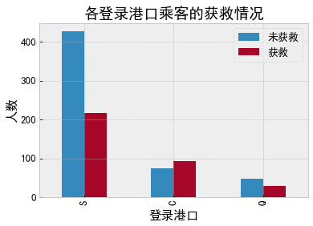

```python
# 各登录港口乘客的获救情况
Survived_0 = data_train.Embarked[data_train.Survived == 0].value_counts()
Survived_1 = data_train.Embarked[data_train.Survived == 1].value_counts()
df=pd.DataFrame({u'获救':Survived_1, u'未获救':Survived_0})
df.plot(kind='bar')
plt.title(u"各登录港口乘客的获救情况")
plt.xlabel(u"登录港口")
plt.ylabel(u"人数")

plt.show()
```

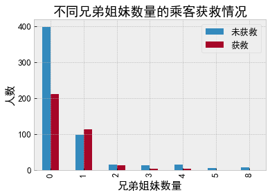

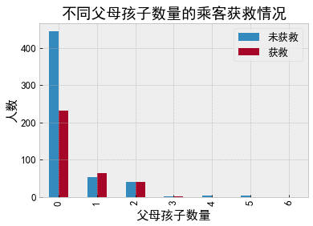

```python
# 兄弟姐妹数量对获救的影响
Survived_0 = data_train.SibSp[data_train.Survived == 0].value_counts()
Survived_1 = data_train.SibSp[data_train.Survived == 1].value_counts()
df = pd.DataFrame({u'获救':Survived_1, u'未获救':Survived_0})
df.plot(kind='bar')
plt.title(u"不同兄弟姐妹数量的乘客获救情况")
plt.xlabel(u"兄弟姐妹数量")
plt.ylabel(u"人数")

fig = plt.figure()
# 孩子父母数量对获救的影响
Survived_0 = data_train.Parch[data_train.Survived == 0].value_counts()
Survived_1 = data_train.Parch[data_train.Survived == 1].value_counts()
df1 = pd.DataFrame({u'获救':Survived_1, u'未获救':Survived_0})
df1.plot(kind='bar')
plt.title(u"不同父母孩子数量的乘客获救情况")
plt.xlabel(u"父母孩子数量")
plt.ylabel(u"人数")

plt.show()
```

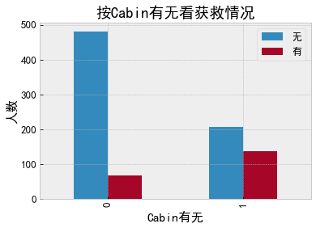

```python
fig = plt.figure()
# 客舱种类太多，因此将客舱先以有无信息来分类
Survived_cabin = data_train.Survived[pd.notnull(data_train.Cabin)].value_counts()
Survived_nocabin = data_train.Survived[pd.isnull(data_train.Cabin)].value_counts()
df=pd.DataFrame({u'有':Survived_cabin, u'无':Survived_nocabin})
df.plot(kind='bar')
plt.title(u"按Cabin有无看获救情况")
plt.xlabel(u"Cabin有无")
plt.ylabel(u"人数")
plt.show()
```

### 结论：

将Cabin按有无缺失值分类,发现无客舱的乘客一大部分都未得救，而有客舱的乘客获救比例却很高。这说明按缺失值这种分类的方法很有效，这种特征也对是否得救有着影响。

```python
# # 船票信息对目标变量的影响
# for data in full_data:
#     # 提取船票数字
#     data['Ticket'] = data.loc[data['Ticket'].notnull(), 'Ticket'].str.extract(r'(\d+$)', expand=False)
#     data.loc[data['Ticket'].isnull(), 'Ticket'] = data.loc[data['Ticket'].notnull(), 'Ticket'].mean

# for data in full_data:
#     data['Ticket'] = data['Ticket'].str.strip().astype(int)


# for data in full_data:
#     # 将船票分段
#     data.loc[((data['Ticket']< data['Ticket'].max)/3), 'Ticket'] = 0
#     data.loc[(data['Ticket']>= data['Ticket'].max/3) & (2*data['Ticket']< data['Ticket'].max/3), 'Ticket'] = 1
#     data.loc[(2*data['Ticket']>= data['Ticket'].max/3) & (data['Ticket']< data['Ticket'].max), 'Ticket'] = 2

# Survived_n = data_train.Name[data_train.Survived == 0].value_counts()
# Survived_y = data_train.Name[data_train.Survived == 1].value_counts()
# df2=pd.DataFrame({u'遇难':Survived_n, u'得救':Survived_y})
# df2.plot(kind='bar')
# plt.title(u"按名称看获救情况")
# plt.xlabel(u"名称")
# plt.ylabel(u"人数")
# plt.show()
```

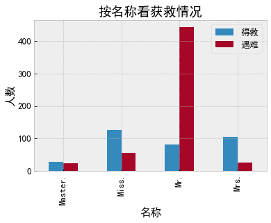

```python
# 名称Name对目标变量的影响
# 合并称呼类别
def merge_title(name):
    female = ['the Countess.', 'Miss.', 'Ms.', 'Mrs.', 'Mme.', 'Mlle.', 'Lady.']
    male = ['Sir.', 'Rev.', 'Mr.', 'Master.', 'Major.', 'Jonkheer.', 'Don.', 'Dr.', 'Col.', 'Capt.']
    name = name.strip().strip()

    if name in female:
        if 'Miss.' in name:
            return name
        else:
            return 'Mrs.'
    elif name in male:
        if name in ['Master.', 'Major.', 'Col.', 'Capt.', 'Dr.']:
            return 'Master.'
        else:
            return 'Mr.'
    else:
        return name


# 提取称号合并称呼类型
for data in full_data:
    data['Name'] = data['Name'].str.extract(r', (.+?\.)', expand=False).apply(merge_title)

# 更改特殊点(有一个Dr为女性),将其Name改为"Mrs."
data_train['Name'] = np.where((data_train['Name']=='Dr.')&(data_train['Sex']==1), 'Mrs.', data_train['Name'])

Survived_n = data_train.Name[data_train.Survived == 0].value_counts()
Survived_y = data_train.Name[data_train.Survived == 1].value_counts()
df2=pd.DataFrame({u'遇难':Survived_n, u'得救':Survived_y})
df2.plot(kind='bar')
plt.title(u"按名称看获救情况")
plt.xlabel(u"名称")
plt.ylabel(u"人数")
plt.show()
```

### 结论：

- 可以看出在female中，Miss与Mrs的生还率差不太多，但是男性中Mr和Master的生还概率差了非常多。Mr生还非常低，而Master高于50%，固这也是一项影响目标变量的因素之一。

## 3.数据处理

由于乘客的Cabin和Age信息有很多缺失值，因此需要对这些缺失值做一些处理。

### 处理年龄缺失值

- 由于很多乘客都缺失年龄值，这里使用随机森林通过已有的特征值拟合年龄来填补缺失年龄值，而非全部直接删除；

### 处理Cabin缺失值

- 按上面数据分析的结果，将Cabin客舱特征按有无缺失值分类效果还不错，下面将无缺失值以"Yes"替换，有缺失值以"No"替换；

```python
### 使用 RandomForestClassifier 填补缺失的年龄属性
def set_missing_ages(df):

    # 把已有的数值型特征取出来丢进Random Forest Regressor中
    age_df = df[['Age','Fare', 'Parch', 'SibSp', 'Pclass']]

    # 乘客分成已知年龄和未知年龄两部分
    known_age = age_df[age_df.Age.notnull()].as_matrix()
    unknown_age = age_df[age_df.Age.isnull()].as_matrix()

    # y即目标年龄
    y = known_age[:, 0]

    # X即特征属性值
    X = known_age[:, 1:]

    # fit到RandomForestRegressor之中
    rfr = RandomForestRegressor(random_state=0, n_estimators=2000, n_jobs=-1)
    rfr.fit(X, y)

    # 用得到的模型进行未知年龄结果预测
    predictedAges = rfr.predict(unknown_age[:, 1:])
#     print predictedAges
    # 用得到的预测结果填补原缺失数据
    df.loc[ (df.Age.isnull()), 'Age' ] = predictedAges

    return df, rfr

def set_Cabin_type(df):
    df.loc[ (df.Cabin.notnull()), 'Cabin' ] = "Yes"
    df.loc[ (df.Cabin.isnull()), 'Cabin' ] = "No"
    return df


data_train, rfr = set_missing_ages(data_train)
for data in full_data:
    data = set_Cabin_type(data)
```

```python
# 填补训练集Embarked缺失值
# data_train.loc[ (data_train.Embarked.isnull()), 'Embarked' ] = 'S'
data_train['Embarked'].fillna('S', inplace=True)

# 填补测试集Fare缺失值
data_test.loc[ (data_test.Fare.isnull()), 'Fare' ] = 0

# 接着我们对test_data做和train_data中一致的特征变换
# 首先用同样的RandomForestRegressor模型填上丢失的年龄
tmp_df = data_test[['Age','Fare', 'Parch', 'SibSp', 'Pclass']]
null_age = tmp_df[data_test.Age.isnull()].as_matrix()

# 根据特征属性X预测年龄并补上
X = null_age[:, 1:]
predictedAges = rfr.predict(X)
data_test.loc[ (data_test.Age.isnull()), 'Age' ] = predictedAges
```

### 特征离散化

```python
# 离散化连续特征信息
for data in full_data:
    # 将年龄分段
    data.loc[(data['Age'] < 16), 'Age'] = 0
    data.loc[(data['Age'] >= 16) & (data['Age'] < 32), 'Age'] = 1
    data.loc[(data['Age'] >= 32) & (data['Age'] < 48), 'Age'] = 2
    data.loc[(data['Age'] >= 48) & (data['Age'] < 64), 'Age'] = 3
    data.loc[(data['Age'] >= 64), 'Age'] = 4

    # 将Fare离散化
    data.loc[(data['Fare'] < 15), 'Fare'] = 0
    data.loc[(data['Fare'] >= 15) & (data['Fare'] < 40), 'Fare'] = 1
    data.loc[(data['Fare'] >= 40) & (data['Fare'] < 65), 'Fare'] = 2
    data.loc[(data['Fare'] >= 65), 'Fare'] = 3

    # 添加姓名长度
#     data['NameLength'] = data['Name'].apply(len)

    # 特征因子化
    data['Sex'] = data['Sex'].map({'female':0, 'male':1})
    data['Name'] = data['Name'].map({'Miss.':0, 'Mrs.':1, 'Mr.':2, 'Master.':3})
    data['Cabin'] = data['Cabin'].map({'No':0, 'Yes':1})
    data['Embarked'] = data['Embarked'].map({'S':0, 'C':1, 'Q':2})

    # 删除tickets
    data.drop(['Ticket'], axis=1, inplace=True)
```

### heatmap分析

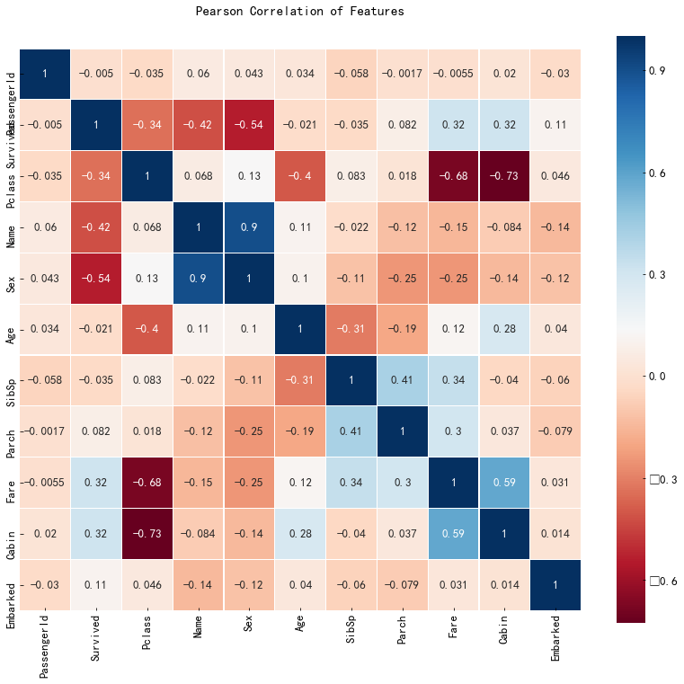

```python
colormap = plt.cm.RdBu
plt.figure(figsize=(14,12))
plt.title('Pearson Correlation of Features', y=1.05, size=15)
sns.heatmap(data_train.astype(float).corr(),linewidths=0.1,vmax=1.0,
            square=True, cmap=colormap, linecolor='white', annot=True)
```

### pairplot分析

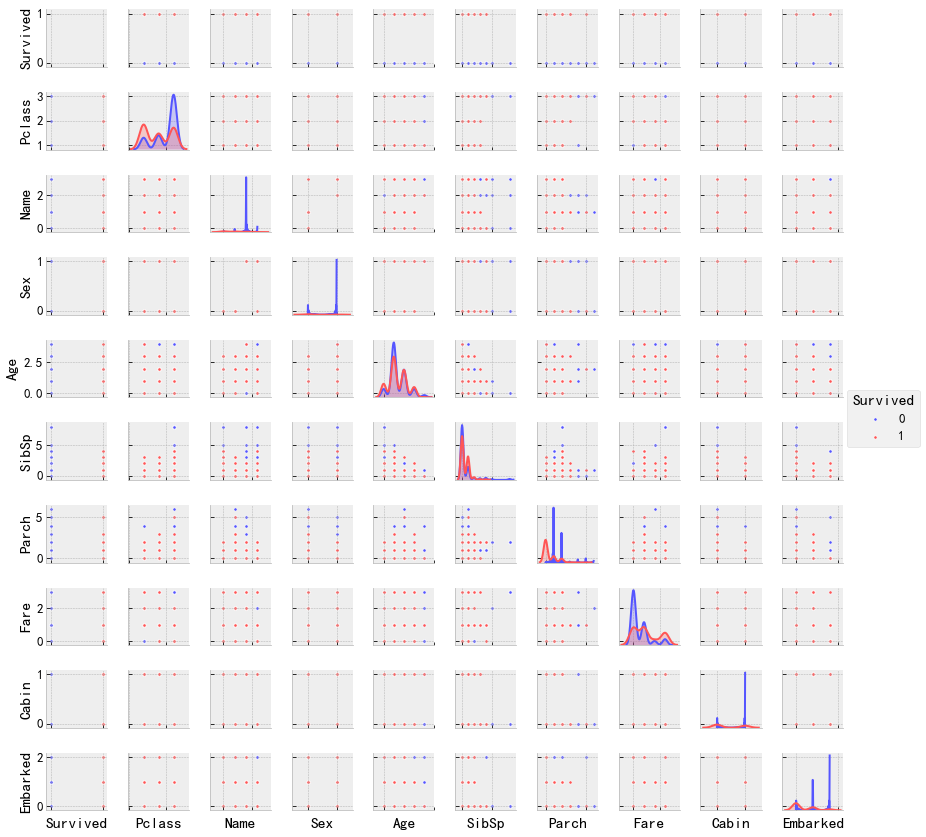

```python
g = sns.pairplot(data_train[[u'Survived', u'Pclass', u'Name', u'Sex', u'Age', u'SibSp', u'Parch', u'Fare', u'Cabin', u'Embarked']],
                             hue='Survived', palette = 'seismic',size=1.2,diag_kind = 'kde',
                             diag_kws=dict(shade=True),plot_kws=dict(s=10) )
g.set(xticklabels=[])
```

### 缺失值检查

```python
for data in full_data:
    print data.info()
display(data_train.head())
```

```
<class 'pandas.core.frame.DataFrame'>
RangeIndex: 891 entries, 0 to 890
Data columns (total 11 columns):
PassengerId    891 non-null int64
Survived       891 non-null int64
Pclass         891 non-null int64
Name           891 non-null int64
Sex            891 non-null int64
Age            891 non-null float64
SibSp          891 non-null int64
Parch          891 non-null int64
Fare           891 non-null float64
Cabin          891 non-null int64
Embarked       891 non-null int64
dtypes: float64(2), int64(9)
memory usage: 76.6 KB
None
<class 'pandas.core.frame.DataFrame'>
RangeIndex: 418 entries, 0 to 417
Data columns (total 10 columns):
PassengerId    418 non-null int64
Pclass         418 non-null int64
Name           417 non-null float64
Sex            418 non-null int64
Age            418 non-null float64
SibSp          418 non-null int64
Parch          418 non-null int64
Fare           418 non-null float64
Cabin          418 non-null int64
Embarked       418 non-null int64
dtypes: float64(3), int64(7)
memory usage: 32.7 KB
None
```

|  | PassengerId | Survived | Pclass | Name | Sex | Age | SibSp | Parch | Fare | Cabin | Embarked |
| --- | --- | --- | --- | --- | --- | --- | --- | --- | --- | --- | --- |
| 0 | 1 | 0 | 3 | 2 | 1 | 1.0 | 1 | 0 | 0.0 | 0 | 0 |
| 1 | 2 | 1 | 1 | 1 | 0 | 2.0 | 1 | 0 | 3.0 | 1 | 1 |
| 2 | 3 | 1 | 3 | 0 | 0 | 1.0 | 0 | 0 | 0.0 | 0 | 0 |
| 3 | 4 | 1 | 1 | 1 | 0 | 2.0 | 1 | 0 | 2.0 | 1 | 0 |
| 4 | 5 | 0 | 3 | 2 | 1 | 2.0 | 0 | 0 | 0.0 | 0 | 0 |

### 特征因子化

- 经过以上数据处理，我们看到很多特征值是类目型，需要的特征需要是数值型。因此，我们要对所有特征进行特征因子化，使用get_dummies实现功能。

```python
# 对Cabin、Embarked、Sex、Name进行特征因子化操作
dummies_Cabin = pd.get_dummies(data_train['Cabin'], prefix= 'Cabin')
dummies_Embarked = pd.get_dummies(data_train['Embarked'], prefix= 'Embarked')
dummies_Sex = pd.get_dummies(data_train['Sex'], prefix= 'Sex')
dummies_Name = pd.get_dummies(data_train['Name'], prefix= 'Name')

# 将特征因子化后的特征信息拼接到原始data_train表上
df = pd.concat([data_train, dummies_Cabin, dummies_Embarked, dummies_Sex, dummies_Name], axis=1)

# 删除特征因子化之前的特征值和无法因子化的特征值 Name
df.drop(['PassengerId', 'Name', 'Sex', 'Cabin', 'Embarked'], axis=1, inplace=True)

df.head()
```

|  | Survived | Pclass | Age | SibSp | Parch | Fare | Cabin_0 | Cabin_1 | Embarked_0 | Embarked_1 | Embarked_2 | Sex_0 | Sex_1 | Name_0 | Name_1 | Name_2 | Name_3 |
| --- | --- | --- | --- | --- | --- | --- | --- | --- | --- | --- | --- | --- | --- | --- | --- | --- | --- |
| 0 | 0 | 3 | 1.0 | 1 | 0 | 0.0 | 1 | 0 | 1 | 0 | 0 | 0 | 1 | 0 | 0 | 1 | 0 |
| 1 | 1 | 1 | 2.0 | 1 | 0 | 3.0 | 0 | 1 | 0 | 1 | 0 | 1 | 0 | 0 | 1 | 0 | 0 |
| 2 | 1 | 3 | 1.0 | 0 | 0 | 0.0 | 1 | 0 | 1 | 0 | 0 | 1 | 0 | 1 | 0 | 0 | 0 |
| 3 | 1 | 1 | 2.0 | 1 | 0 | 2.0 | 0 | 1 | 1 | 0 | 0 | 1 | 0 | 0 | 1 | 0 | 0 |
| 4 | 0 | 3 | 2.0 | 0 | 0 | 0.0 | 1 | 0 | 1 | 0 | 0 | 0 | 1 | 0 | 0 | 1 | 0 |

### 测试集数据处理

- 同样的，测试也必须使用与训练集一样的数据预处理方法。

```python
dummies_test_Cabin = pd.get_dummies(data_test['Cabin'], prefix= 'Cabin')
dummies_test_Embarked = pd.get_dummies(data_test['Embarked'], prefix= 'Embarked')
dummies_test_Sex = pd.get_dummies(data_test['Sex'], prefix= 'Sex')
dummies_test_Name = pd.get_dummies(data_test['Name'], prefix= 'Name')

df_test = pd.concat([data_test, dummies_test_Cabin, dummies_test_Embarked, dummies_test_Sex, dummies_test_Name], axis=1)
df_test.drop(['PassengerId', 'Name', 'Sex', 'Cabin', 'Embarked'], axis=1, inplace=True)

df_test.head()
```

|  | Pclass | Age | SibSp | Parch | Fare | Cabin_0 | Cabin_1 | Embarked_0 | Embarked_1 | Embarked_2 | Sex_0 | Sex_1 | Name_0.0 | Name_1.0 | Name_2.0 | Name_3.0 |
| --- | --- | --- | --- | --- | --- | --- | --- | --- | --- | --- | --- | --- | --- | --- | --- | --- |
| 0 | 3 | 2.0 | 0 | 0 | 0.0 | 1 | 0 | 0 | 0 | 1 | 0 | 1 | 0 | 0 | 1 | 0 |
| 1 | 3 | 2.0 | 1 | 0 | 0.0 | 1 | 0 | 1 | 0 | 0 | 1 | 0 | 0 | 1 | 0 | 0 |
| 2 | 2 | 3.0 | 0 | 0 | 0.0 | 1 | 0 | 0 | 0 | 1 | 0 | 1 | 0 | 0 | 1 | 0 |
| 3 | 3 | 1.0 | 0 | 0 | 0.0 | 1 | 0 | 1 | 0 | 0 | 0 | 1 | 0 | 0 | 1 | 0 |
| 4 | 3 | 1.0 | 1 | 1 | 0.0 | 1 | 0 | 1 | 0 | 0 | 1 | 0 | 0 | 1 | 0 | 0 |

## 4.集成学习stacking模型

```python
ntrain = data_train.shape[0]
ntest = data_test.shape[0]
SEED = 0 # for reproducibility
NFOLDS = 10 # set folds for out-of-fold prediction
kf = KFold(n_splits=NFOLDS) # 建立k折

# Class to extend the Sklearn classifier
class SklearnHelper(object):
    def __init__(self, clf, seed=0, params=None):
        params['random_state'] = seed
        self.clf = clf(**params)

    def train(self, x_train, y_train):
        self.clf.fit(x_train, y_train)

    def predict(self, x):
        return self.clf.predict(x)

    def fit(self,x,y):
        return self.clf.fit(x,y)

    def feature_importances(self,x,y):
        print(self.clf.fit(x,y).feature_importances_)
```

### 交叉认证—K折

```python
def get_oof(clf, x_train, y_train, x_test):
    oof_train = np.zeros((ntrain,))
    oof_test = np.zeros((ntest,))
    oof_test_skf = np.empty((NFOLDS, ntest))

    for i, (train_index, test_index) in enumerate(kf.split(x_train, y_train)):
        x_tr = x_train[train_index]
        y_tr = y_train[train_index]
        x_te = x_train[test_index]

        clf.train(x_tr, y_tr)

        oof_train[test_index] = clf.predict(x_te)
        oof_test_skf[i, :] = clf.predict(x_test)

    oof_test[:] = oof_test_skf.mean(axis=0)
    return oof_train.reshape(-1, 1), oof_test.reshape(-1, 1)
```

### 建立一级模型

- Random Forest classifier
- Extra Trees classifier
- AdaBoost classifer
- Gradient Boosting classifer
- Support Vector Machine

```python
# Put in our parameters for said classifiers
# Random Forest parameters
rf_params = {
    'n_jobs': -1,
    'n_estimators': 500,
     'warm_start': True,
     #'max_features': 0.2,
    'max_depth': 6,
    'min_samples_leaf': 2,
    'max_features' : 'sqrt',
    'verbose': 0
}

# Extra Trees Parameters
et_params = {
    'n_jobs': -1,
    'n_estimators':500,
    #'max_features': 0.5,
    'max_depth': 8,
    'min_samples_leaf': 2,
    'verbose': 0
}

# AdaBoost parameters
ada_params = {
    'n_estimators': 1000,
    'learning_rate' : 0.75
}

# Gradient Boosting parameters
gb_params = {
    'n_estimators': 500,
     #'max_features': 0.2,
    'max_depth': 5,
    'min_samples_leaf': 2,
    'verbose': 0
}

# Support Vector Classifier parameters
svc_params = {
    'kernel' : 'linear',
    'C' : 0.025
    }
```

```python
# 模型建立
rf = SklearnHelper(clf=RandomForestClassifier, seed=SEED, params = rf_params) # 随即森林
# et = SklearnHelper(clf=ExtraTreesClassifier, seed=SEED, params=et_params) # Extra树
ada = SklearnHelper(clf=AdaBoostClassifier, seed=SEED, params=ada_params) # Adaboost
gb = SklearnHelper(clf=GradientBoostingClassifier, seed=SEED, params=gb_params) # 上升树
svc = SklearnHelper(clf=SVC, seed=SEED, params=svc_params) # SVM
```

### 训练集数据转换为Numpy array

```python
# 将训练集数据进行划分

x_train = df.drop(['Survived'], axis=1)
y_train = df['Survived'].ravel()

# 转换为ndarray数组
x_train = np.array(x_train)
x_test = np.array(df_test)
```

### 预测模型

```python
# Create our OOF train and test predictions. These base results will be used as new features
# et_oof_train, et_oof_test = get_oof(et, x_train, y_train, x_test) # Extra Trees
rf_oof_train, rf_oof_test = get_oof(rf,x_train, y_train, x_test) # Random Forest
ada_oof_train, ada_oof_test = get_oof(ada, x_train, y_train, x_test) # AdaBoost
gb_oof_train, gb_oof_test = get_oof(gb,x_train, y_train, x_test) # Gradient Boost
svc_oof_train, svc_oof_test = get_oof(svc,x_train, y_train, x_test) # Support Vector Classifier

print("Training is complete")
```

```
Training is complete
```

```python
base_predictions_train = pd.DataFrame( {'RandomForest': rf_oof_train.ravel(),
#      'ExtraTrees': et_oof_train.ravel(),
     'AdaBoost': ada_oof_train.ravel(),
     'GradientBoost': gb_oof_train.ravel(),
     'SVC': svc_oof_train.ravel()
    })
base_predictions_train.head()
```

[output not shown]

```python
x_train = np.concatenate(( et_oof_train, rf_oof_train, ada_oof_train, gb_oof_train, svc_oof_train), axis=1)
x_test = np.concatenate(( et_oof_test, rf_oof_test, ada_oof_test, gb_oof_test, svc_oof_test), axis=1)
```

### 二级模型交叉认证求最优参数

```python
#
x2_train, x2_test, y2_train, y2_test = train_test_split(x_train, y_train, test_size = 0.2, random_state = 0)

# 利用GridSearchCV计算最优解
def fit_model(X, y):
    """ 基于输入数据 [X,y]，利于网格搜索找到最优的决策树模型"""

    cross_validator = KFold(2, shuffle=True)

    gbm = DecisionTreeClassifier()

    params = {}
    params['max_depth'] = [1,2,3,4,5,6,7,8,9,10]
#     params['n_estimators'] = [1000, 2000]

    scoring_fnc = make_scorer(performance_metric)

    grid = GridSearchCV(estimator = gbm, param_grid = params, scoring = scoring_fnc, cv = cross_validator)

    # 基于输入数据 [X,y]，进行网格搜索
    grid = grid.fit(X, y)
    print grid
#     print pd.DataFrame(grid.cv_results_)
    return grid.best_estimator_

# 计算R2分数
def performance_metric(y_true, y_predict):
    """计算并返回预测值相比于预测值的分数"""
    from sklearn.metrics import r2_score
    score = r2_score(y_true, y_predict)

    return score
```

```python
optimal_estimator = fit_model(x2_train, y2_train)
predictions = optimal_estimator.predict(x_test)
```

```
GridSearchCV(cv=KFold(n_splits=2, random_state=None, shuffle=True),
       error_score='raise',
       estimator=DecisionTreeClassifier(class_weight=None, criterion='gini', max_depth=None,
            max_features=None, max_leaf_nodes=None,
            min_impurity_decrease=0.0, min_impurity_split=None,
            min_samples_leaf=1, min_samples_split=2,
            min_weight_fraction_leaf=0.0, presort=False, random_state=None,
            splitter='best'),
       fit_params=None, iid=True, n_jobs=1,
       param_grid={'max_depth': [1, 2, 3, 4, 5, 6, 7, 8, 9, 10]},
       pre_dispatch='2*n_jobs', refit=True, return_train_score='warn',
       scoring=make_scorer(performance_metric), verbose=0)
```

```python
gbm = xgb.XGBClassifier(
 learning_rate = 0.02,
 n_estimators= 2000,
 max_depth= 4,
 min_child_weight= 2,
#  gamma=1,
 gamma=0.9,
 subsample=0.8,
 colsample_bytree=0.8,
 objective= 'binary:logistic',
 nthread= -1,
 scale_pos_weight=1).fit(x_train, y_train)
predictions = gbm.predict(x_test)
```

```python
# Generate Submission File
StackingSubmission = pd.DataFrame({ 'PassengerId': data_test['PassengerId'],
                            'Survived': predictions })
StackingSubmission.to_csv("StackingSubmission.csv", index=False)
```

## 6.总结

本项目完成了对 Taitanic 生还者的预测和分析，结果拿到Kaggle进行测试，预测准确率为 `0.80380`，还有很多的上升的空间。

通过本项目学习了机器学习建模的过程和优化过程，后续将会不断完善模型。